# Risk Factor Analysis

## Outcome Variable

**Outcome Variable:** y_rate_haz

## Predictor Variables

**Intervention Variable:** perdiar6

**Adjustment Set:**

- arm
- sex
- W_mage
- meducyrs
- feducyrs
- hfoodsec
- W_mhtcm
- W_mwtkg
- W_mbmi
- W_birthwt
- W_birthlen
- W_nrooms
- month
- brthmon
- impfloor
- impsan
- safeh20
- delta_W_mage
- delta_meducyrs
- delta_feducyrs
- delta_hfoodsec
- delta_W_mhtcm
- delta_W_mwtkg
- delta_W_mbmi
- delta_W_birthwt
- delta_W_birthlen
- delta_W_nrooms
- delta_month
- delta_brthmon
- delta_impfloor
- delta_impsan
- delta_safeh20

## Stratifying Variables

The analysis was stratified on these variable(s):

- agecat
- studyid
- country

## Data Summary

| agecat | studyid | country | perdiar6 | n_cell | n |
| --- | --- | --- | --- | --- | --- |
| 0-3 months | ki0047075b-MAL-ED | BANGLADESH | Q1 | 243 | 244 |
| 0-3 months | ki0047075b-MAL-ED | BANGLADESH | Q2 | 1 | 244 |
| 0-3 months | ki1017093-NIH-Birth | BANGLADESH | Q1 | 554 | 566 |
| 0-3 months | ki1017093-NIH-Birth | BANGLADESH | Q2 | 12 | 566 |
| 0-3 months | ki1017093b-PROVIDE | BANGLADESH | Q1 | 629 | 634 |
| 0-3 months | ki1017093b-PROVIDE | BANGLADESH | Q2 | 5 | 634 |
| 0-3 months | ki1017093c-NIH-Crypto | BANGLADESH | Q1 | 716 | 720 |
| 0-3 months | ki1017093c-NIH-Crypto | BANGLADESH | Q2 | 4 | 720 |
| 0-3 months | ki1114097-CMIN | BANGLADESH | Q1 | 41 | 43 |
| 0-3 months | ki1114097-CMIN | BANGLADESH | Q2 | 2 | 43 |
| 0-3 months | ki0047075b-MAL-ED | BRAZIL | Q1 | 180 | 180 |
| 0-3 months | ki1114097-CMIN | BRAZIL | Q1 | 81 | 81 |
| 0-3 months | ki1114097-CMIN | GUINEA-BISSAU | Q1 | 21 | 21 |
| 0-3 months | ki0047075b-MAL-ED | INDIA | Q1 | 200 | 201 |
| 0-3 months | ki0047075b-MAL-ED | INDIA | Q2 | 1 | 201 |
| 0-3 months | ki0047075b-MAL-ED | NEPAL | Q1 | 172 | 175 |
| 0-3 months | ki0047075b-MAL-ED | NEPAL | Q2 | 3 | 175 |
| 0-3 months | ki1000109-ResPak | PAKISTAN | Q1 | 73 | 78 |
| 0-3 months | ki1000109-ResPak | PAKISTAN | Q2 | 5 | 78 |
| 0-3 months | ki0047075b-MAL-ED | PERU | Q1 | 266 | 271 |
| 0-3 months | ki0047075b-MAL-ED | PERU | Q2 | 5 | 271 |
| 0-3 months | ki1114097-CMIN | PERU | Q1 | 88 | 93 |
| 0-3 months | ki1114097-CMIN | PERU | Q2 | 5 | 93 |
| 0-3 months | ki1114097-CONTENT | PERU | Q1 | 29 | 29 |
| 0-3 months | ki0047075b-MAL-ED | SOUTH AFRICA | Q1 | 229 | 229 |
| 0-3 months | ki0047075b-MAL-ED | TANZANIA, UNITED REPUBLIC OF | Q1 | 229 | 229 |
| 3-6 months | ki0047075b-MAL-ED | BANGLADESH | Q1 | 230 | 231 |
| 3-6 months | ki0047075b-MAL-ED | BANGLADESH | Q2 | 1 | 231 |
| 3-6 months | ki1017093-NIH-Birth | BANGLADESH | Q1 | 516 | 523 |
| 3-6 months | ki1017093-NIH-Birth | BANGLADESH | Q2 | 7 | 523 |

[output cut: 83 more lines]

The following strata were considered:

- agecat: 0-3 months, studyid: ki0047075b-MAL-ED, country: BANGLADESH
- agecat: 0-3 months, studyid: ki0047075b-MAL-ED, country: BRAZIL
- agecat: 0-3 months, studyid: ki0047075b-MAL-ED, country: INDIA
- agecat: 0-3 months, studyid: ki0047075b-MAL-ED, country: NEPAL
- agecat: 0-3 months, studyid: ki0047075b-MAL-ED, country: PERU
- agecat: 0-3 months, studyid: ki0047075b-MAL-ED, country: SOUTH AFRICA
- agecat: 0-3 months, studyid: ki0047075b-MAL-ED, country: TANZANIA, UNITED REPUBLIC OF
- agecat: 0-3 months, studyid: ki1000109-ResPak, country: PAKISTAN
- agecat: 0-3 months, studyid: ki1017093-NIH-Birth, country: BANGLADESH
- agecat: 0-3 months, studyid: ki1017093b-PROVIDE, country: BANGLADESH
- agecat: 0-3 months, studyid: ki1017093c-NIH-Crypto, country: BANGLADESH
- agecat: 0-3 months, studyid: ki1114097-CMIN, country: BANGLADESH
- agecat: 0-3 months, studyid: ki1114097-CMIN, country: BRAZIL
- agecat: 0-3 months, studyid: ki1114097-CMIN, country: GUINEA-BISSAU
- agecat: 0-3 months, studyid: ki1114097-CMIN, country: PERU
- agecat: 0-3 months, studyid: ki1114097-CONTENT, country: PERU
- agecat: 12-24 months, studyid: ki0047075b-MAL-ED, country: BANGLADESH
- agecat: 12-24 months, studyid: ki0047075b-MAL-ED, country: BRAZIL
- agecat: 12-24 months, studyid: ki0047075b-MAL-ED, country: INDIA
- agecat: 12-24 months, studyid: ki0047075b-MAL-ED, country: NEPAL
- agecat: 12-24 months, studyid: ki0047075b-MAL-ED, country: PERU
- agecat: 12-24 months, studyid: ki0047075b-MAL-ED, country: SOUTH AFRICA
- agecat: 12-24 months, studyid: ki0047075b-MAL-ED, country: TANZANIA, UNITED REPUBLIC OF
- agecat: 12-24 months, studyid: ki1017093-NIH-Birth, country: BANGLADESH
- agecat: 12-24 months, studyid: ki1017093b-PROVIDE, country: BANGLADESH
- agecat: 12-24 months, studyid: ki1017093c-NIH-Crypto, country: BANGLADESH
- agecat: 12-24 months, studyid: ki1114097-CMIN, country: BANGLADESH
- agecat: 12-24 months, studyid: ki1114097-CMIN, country: GUINEA-BISSAU
- agecat: 12-24 months, studyid: ki1114097-CMIN, country: PERU
- agecat: 12-24 months, studyid: ki1114097-CONTENT, country: PERU
- agecat: 3-6 months, studyid: ki0047075b-MAL-ED, country: BANGLADESH
- agecat: 3-6 months, studyid: ki0047075b-MAL-ED, country: BRAZIL
- agecat: 3-6 months, studyid: ki0047075b-MAL-ED, country: INDIA
- agecat: 3-6 months, studyid: ki0047075b-MAL-ED, country: NEPAL
- agecat: 3-6 months, studyid: ki0047075b-MAL-ED, country: PERU
- agecat: 3-6 months, studyid: ki0047075b-MAL-ED, country: SOUTH AFRICA
- agecat: 3-6 months, studyid: ki0047075b-MAL-ED, country: TANZANIA, UNITED REPUBLIC OF
- agecat: 3-6 months, studyid: ki1000109-ResPak, country: PAKISTAN
- agecat: 3-6 months, studyid: ki1017093-NIH-Birth, country: BANGLADESH
- agecat: 3-6 months, studyid: ki1017093b-PROVIDE, country: BANGLADESH
- agecat: 3-6 months, studyid: ki1017093c-NIH-Crypto, country: BANGLADESH
- agecat: 3-6 months, studyid: ki1114097-CMIN, country: BANGLADESH
- agecat: 3-6 months, studyid: ki1114097-CMIN, country: BRAZIL
- agecat: 3-6 months, studyid: ki1114097-CMIN, country: GUINEA-BISSAU
- agecat: 3-6 months, studyid: ki1114097-CMIN, country: PERU
- agecat: 3-6 months, studyid: ki1114097-CONTENT, country: PERU
- agecat: 6-12 months, studyid: ki0047075b-MAL-ED, country: BANGLADESH
- agecat: 6-12 months, studyid: ki0047075b-MAL-ED, country: BRAZIL
- agecat: 6-12 months, studyid: ki0047075b-MAL-ED, country: INDIA
- agecat: 6-12 months, studyid: ki0047075b-MAL-ED, country: NEPAL
- agecat: 6-12 months, studyid: ki0047075b-MAL-ED, country: PERU
- agecat: 6-12 months, studyid: ki0047075b-MAL-ED, country: SOUTH AFRICA
- agecat: 6-12 months, studyid: ki0047075b-MAL-ED, country: TANZANIA, UNITED REPUBLIC OF
- agecat: 6-12 months, studyid: ki1000109-ResPak, country: PAKISTAN
- agecat: 6-12 months, studyid: ki1017093-NIH-Birth, country: BANGLADESH
- agecat: 6-12 months, studyid: ki1017093b-PROVIDE, country: BANGLADESH
- agecat: 6-12 months, studyid: ki1017093c-NIH-Crypto, country: BANGLADESH
- agecat: 6-12 months, studyid: ki1114097-CMIN, country: BANGLADESH
- agecat: 6-12 months, studyid: ki1114097-CMIN, country: BRAZIL
- agecat: 6-12 months, studyid: ki1114097-CMIN, country: GUINEA-BISSAU
- agecat: 6-12 months, studyid: ki1114097-CMIN, country: PERU
- agecat: 6-12 months, studyid: ki1114097-CONTENT, country: PERU

### Dropped Strata

Some strata were dropped due to rare outcomes:

- agecat: 0-3 months, studyid: ki0047075b-MAL-ED, country: BANGLADESH
- agecat: 0-3 months, studyid: ki1017093c-NIH-Crypto, country: BANGLADESH
- agecat: 0-3 months, studyid: ki1114097-CMIN, country: BANGLADESH
- agecat: 0-3 months, studyid: ki0047075b-MAL-ED, country: INDIA
- agecat: 0-3 months, studyid: ki0047075b-MAL-ED, country: NEPAL
- agecat: 3-6 months, studyid: ki0047075b-MAL-ED, country: BANGLADESH
- agecat: 3-6 months, studyid: ki1017093b-PROVIDE, country: BANGLADESH
- agecat: 3-6 months, studyid: ki1017093c-NIH-Crypto, country: BANGLADESH
- agecat: 3-6 months, studyid: ki1114097-CMIN, country: BANGLADESH
- agecat: 3-6 months, studyid: ki0047075b-MAL-ED, country: INDIA
- agecat: 3-6 months, studyid: ki0047075b-MAL-ED, country: NEPAL
- agecat: 3-6 months, studyid: ki0047075b-MAL-ED, country: PERU
- agecat: 3-6 months, studyid: ki1114097-CMIN, country: PERU
- agecat: 3-6 months, studyid: ki1114097-CONTENT, country: PERU
- agecat: 6-12 months, studyid: ki0047075b-MAL-ED, country: BANGLADESH
- agecat: 6-12 months, studyid: ki1017093-NIH-Birth, country: BANGLADESH
- agecat: 6-12 months, studyid: ki1017093b-PROVIDE, country: BANGLADESH
- agecat: 6-12 months, studyid: ki1017093c-NIH-Crypto, country: BANGLADESH
- agecat: 6-12 months, studyid: ki1114097-CMIN, country: BANGLADESH
- agecat: 6-12 months, studyid: ki1114097-CMIN, country: BRAZIL
- agecat: 6-12 months, studyid: ki0047075b-MAL-ED, country: INDIA
- agecat: 6-12 months, studyid: ki0047075b-MAL-ED, country: NEPAL
- agecat: 6-12 months, studyid: ki0047075b-MAL-ED, country: PERU
- agecat: 6-12 months, studyid: ki1114097-CMIN, country: PERU
- agecat: 6-12 months, studyid: ki1114097-CONTENT, country: PERU
- agecat: 12-24 months, studyid: ki0047075b-MAL-ED, country: BANGLADESH
- agecat: 12-24 months, studyid: ki1017093-NIH-Birth, country: BANGLADESH
- agecat: 12-24 months, studyid: ki1017093b-PROVIDE, country: BANGLADESH
- agecat: 12-24 months, studyid: ki1017093c-NIH-Crypto, country: BANGLADESH
- agecat: 12-24 months, studyid: ki1114097-CMIN, country: BANGLADESH
- agecat: 12-24 months, studyid: ki0047075b-MAL-ED, country: INDIA
- agecat: 12-24 months, studyid: ki0047075b-MAL-ED, country: NEPAL
- agecat: 12-24 months, studyid: ki0047075b-MAL-ED, country: PERU
- agecat: 12-24 months, studyid: ki1114097-CMIN, country: PERU
- agecat: 12-24 months, studyid: ki1114097-CONTENT, country: PERU

## Methods Detail

We’re interested in the causal parameters $E[Y_a]$ for all values of $a \in \mathcal{A}$. These parameters represent the mean outcome if, possibly contrary to fact, we intervened to set all units to have $A=a$. Under the randomization and positivity assumptions, these are identified by the statistical parameters $\psi_a=E_W[E_{Y|A,W}(Y|A=a,W)]$. In addition, we’re interested in the mean of $Y$, $E[Y]$ under no intervention (the observed mean). We will estimate these parameters by using SuperLearner to fit the relevant likelihood factors – $E_{Y|A,W}(Y|A=a,W)$ and $p(A=a|W)$, and then updating our likelihood fit using a joint TMLE.

For unadjusted analyses ($W=\{\}$), initial likelihoods were estimated using Lrnr_glm to estimate the simple $E(Y|A)$ and Lrnr_mean to estimate $p(A)$. For adjusted analyses, a small library containing Lrnr_glmnet, Lrnr_xgboost, and Lrnr_mean was used.

[output not shown]

[output cut: 275 more lines]

[output not shown]

[output not shown]

[output not shown]

[output cut: 791 more lines]

[output not shown]

[output not shown]

[output not shown]

[output not shown]

[output not shown]

[output cut: 143 more lines]

[output not shown]

[output not shown]

[output not shown]

[output cut: 2453 more lines]

[output not shown]

[output not shown]

[output not shown]

[output not shown]

[output cut: 95 more lines]

[output not shown]

[output not shown]

[output not shown]

[output cut: 1169 more lines]

[output not shown]

[output not shown]

[output not shown]

# Results Detail

## Results Plots

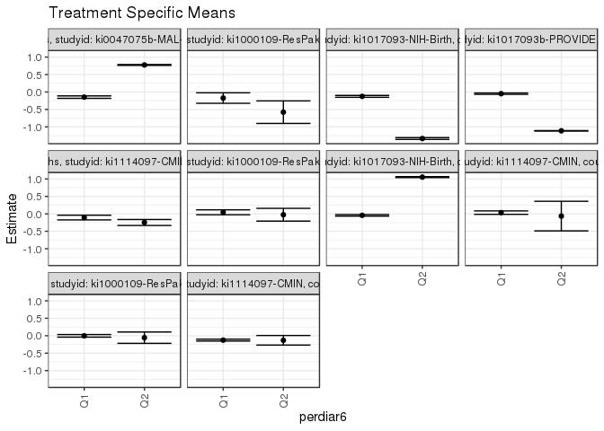

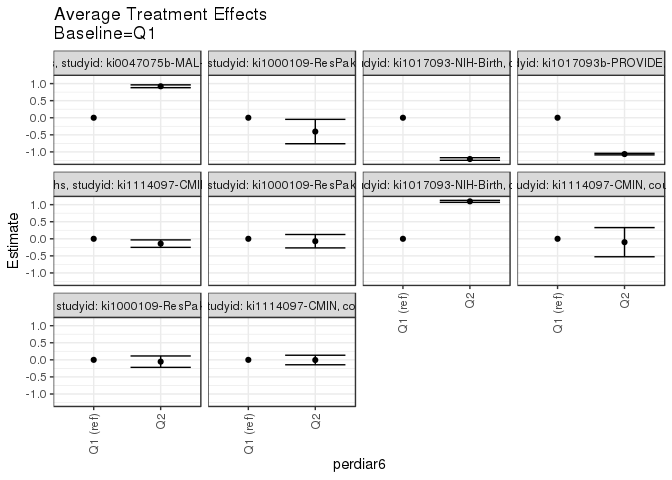

## Results Table

### Parameter: TSM

| agecat | studyid | country | intervention_level | baseline_level | estimate | ci_lower | ci_upper |
| --- | --- | --- | --- | --- | --- | --- | --- |
| 0-3 months | ki0047075b-MAL-ED | PERU | Q1 | NA | -0.1472664 | -0.1823211 | -0.1122118 |
| 0-3 months | ki0047075b-MAL-ED | PERU | Q2 | NA | 0.7744946 | 0.7622457 | 0.7867434 |
| 0-3 months | ki1000109-ResPak | PAKISTAN | Q1 | NA | -0.1738483 | -0.3236836 | -0.0240130 |
| 0-3 months | ki1000109-ResPak | PAKISTAN | Q2 | NA | -0.5786002 | -0.9012834 | -0.2559171 |
| 0-3 months | ki1017093-NIH-Birth | BANGLADESH | Q1 | NA | -0.1257948 | -0.1528355 | -0.0987542 |
| 0-3 months | ki1017093-NIH-Birth | BANGLADESH | Q2 | NA | -1.3344426 | -1.3608057 | -1.3080796 |
| 0-3 months | ki1017093b-PROVIDE | BANGLADESH | Q1 | NA | -0.0487231 | -0.0682867 | -0.0291596 |
| 0-3 months | ki1017093b-PROVIDE | BANGLADESH | Q2 | NA | -1.1130030 | -1.1199652 | -1.1060407 |
| 0-3 months | ki1114097-CMIN | PERU | Q1 | NA | -0.1059852 | -0.1733729 | -0.0385974 |
| 0-3 months | ki1114097-CMIN | PERU | Q2 | NA | -0.2472662 | -0.3325163 | -0.1620161 |
| 3-6 months | ki1000109-ResPak | PAKISTAN | Q1 | NA | 0.0446875 | -0.0256185 | 0.1149935 |
| 3-6 months | ki1000109-ResPak | PAKISTAN | Q2 | NA | -0.0257113 | -0.2087702 | 0.1573476 |
| 3-6 months | ki1017093-NIH-Birth | BANGLADESH | Q1 | NA | -0.0423110 | -0.0652168 | -0.0194052 |
| 3-6 months | ki1017093-NIH-Birth | BANGLADESH | Q2 | NA | 1.0533909 | 1.0405603 | 1.0662214 |
| 3-6 months | ki1114097-CMIN | GUINEA-BISSAU | Q1 | NA | 0.0350009 | -0.0135283 | 0.0835300 |
| 3-6 months | ki1114097-CMIN | GUINEA-BISSAU | Q2 | NA | -0.0640917 | -0.4883155 | 0.3601321 |
| 6-12 months | ki1000109-ResPak | PAKISTAN | Q1 | NA | -0.0035106 | -0.0407866 | 0.0337653 |
| 6-12 months | ki1000109-ResPak | PAKISTAN | Q2 | NA | -0.0561887 | -0.2189865 | 0.1066091 |
| 6-12 months | ki1114097-CMIN | GUINEA-BISSAU | Q1 | NA | -0.1264735 | -0.1535150 | -0.0994320 |
| 6-12 months | ki1114097-CMIN | GUINEA-BISSAU | Q2 | NA | -0.1312312 | -0.2685025 | 0.0060401 |

### Parameter: E(Y)

| agecat | studyid | country | intervention_level | baseline_level | estimate | ci_lower | ci_upper |
| --- | --- | --- | --- | --- | --- | --- | --- |
| 0-3 months | ki0047075b-MAL-ED | PERU | NA | NA | -0.1581085 | -0.1906285 | -0.1255886 |
| 0-3 months | ki1000109-ResPak | PAKISTAN | NA | NA | -0.1934958 | -0.3384003 | -0.0485914 |
| 0-3 months | ki1017093-NIH-Birth | BANGLADESH | NA | NA | -0.1191165 | -0.1460676 | -0.0921654 |
| 0-3 months | ki1017093b-PROVIDE | BANGLADESH | NA | NA | -0.0413143 | -0.0594662 | -0.0231624 |
| 0-3 months | ki1114097-CMIN | PERU | NA | NA | -0.1173363 | -0.1825933 | -0.0520792 |
| 3-6 months | ki1000109-ResPak | PAKISTAN | NA | NA | 0.0387792 | -0.0275800 | 0.1051384 |
| 3-6 months | ki1017093-NIH-Birth | BANGLADESH | NA | NA | -0.0509007 | -0.0730097 | -0.0287917 |
| 3-6 months | ki1114097-CMIN | GUINEA-BISSAU | NA | NA | 0.0319654 | -0.0174743 | 0.0814052 |
| 6-12 months | ki1000109-ResPak | PAKISTAN | NA | NA | -0.0070783 | -0.0435451 | 0.0293884 |
| 6-12 months | ki1114097-CMIN | GUINEA-BISSAU | NA | NA | -0.1267385 | -0.1535471 | -0.0999299 |

### Parameter: ATE

| agecat | studyid | country | intervention_level | baseline_level | estimate | ci_lower | ci_upper |
| --- | --- | --- | --- | --- | --- | --- | --- |
| 0-3 months | ki0047075b-MAL-ED | PERU | Q1 | Q1 | 0.0000000 | 0.0000000 | 0.0000000 |
| 0-3 months | ki0047075b-MAL-ED | PERU | Q2 | Q1 | 0.9217610 | 0.8807712 | 0.9627508 |
| 0-3 months | ki1000109-ResPak | PAKISTAN | Q1 | Q1 | 0.0000000 | 0.0000000 | 0.0000000 |
| 0-3 months | ki1000109-ResPak | PAKISTAN | Q2 | Q1 | -0.4047520 | -0.7614343 | -0.0480696 |
| 0-3 months | ki1017093-NIH-Birth | BANGLADESH | Q1 | Q1 | 0.0000000 | 0.0000000 | 0.0000000 |
| 0-3 months | ki1017093-NIH-Birth | BANGLADESH | Q2 | Q1 | -1.2086478 | -1.2468247 | -1.1704708 |
| 0-3 months | ki1017093b-PROVIDE | BANGLADESH | Q1 | Q1 | 0.0000000 | 0.0000000 | 0.0000000 |
| 0-3 months | ki1017093b-PROVIDE | BANGLADESH | Q2 | Q1 | -1.0642799 | -1.0872489 | -1.0413108 |
| 0-3 months | ki1114097-CMIN | PERU | Q1 | Q1 | 0.0000000 | 0.0000000 | 0.0000000 |
| 0-3 months | ki1114097-CMIN | PERU | Q2 | Q1 | -0.1412811 | -0.2508106 | -0.0317515 |
| 3-6 months | ki1000109-ResPak | PAKISTAN | Q1 | Q1 | 0.0000000 | 0.0000000 | 0.0000000 |
| 3-6 months | ki1000109-ResPak | PAKISTAN | Q2 | Q1 | -0.0703988 | -0.2662876 | 0.1254899 |
| 3-6 months | ki1017093-NIH-Birth | BANGLADESH | Q1 | Q1 | 0.0000000 | 0.0000000 | 0.0000000 |
| 3-6 months | ki1017093-NIH-Birth | BANGLADESH | Q2 | Q1 | 1.0957019 | 1.0670316 | 1.1243722 |
| 3-6 months | ki1114097-CMIN | GUINEA-BISSAU | Q1 | Q1 | 0.0000000 | 0.0000000 | 0.0000000 |
| 3-6 months | ki1114097-CMIN | GUINEA-BISSAU | Q2 | Q1 | -0.0990926 | -0.5261786 | 0.3279935 |
| 6-12 months | ki1000109-ResPak | PAKISTAN | Q1 | Q1 | 0.0000000 | 0.0000000 | 0.0000000 |
| 6-12 months | ki1000109-ResPak | PAKISTAN | Q2 | Q1 | -0.0526780 | -0.2196372 | 0.1142811 |
| 6-12 months | ki1114097-CMIN | GUINEA-BISSAU | Q1 | Q1 | 0.0000000 | 0.0000000 | 0.0000000 |
| 6-12 months | ki1114097-CMIN | GUINEA-BISSAU | Q2 | Q1 | -0.0047577 | -0.1442026 | 0.1346872 |